# Classification through GMM for the centar of mass $(r_\text{cm})$ of exoplanetary systems.

We use Gaussian Mixture Model to clasify the center of mass of exoplanetary systems, employing the observational data

## 1. Read and clean the file from exoplanet.eu

From the most complete list of observed exoplanets planets to date, [exoplanet.eu](http://exoplanet.eu/), we take the planetary mass $M_{tp}$, the semi_major $a$ and the Metallicity Fe/H (with their respective uncertainties).

It is necessary processing the data with the prurpose to obtain the Center of Mass $r_\text{cm}$, as a DataFrame `data`, without NaN values in the columns of *mass* ($M_{tp}$) and *semi major axis*($a$). Finally, we get the data cleaned.

**Remember**: `pd.notnull("name_of_column")` deletes the NaN values in the column.

**Remember**: `data=data[['column_a','column_b',..,'column_n',]]` to get a new order in the DataFrame

```python
import pandas as pd;
import numpy as np
from scipy.stats import norm
import random
from sklearn.mixture import GaussianMixture
import matplotlib.pyplot as plt
import seaborn as sb
from matplotlib import rc, cm, rcParams

rcParams['text.latex.preamble']=[r"\usepackage{amsmath}"]
rc('text', usetex=True)
%matplotlib inline
```

Now, the data is read (only mass and semi major axis with their uncertainties).

```python
data_ep = pd.read_csv('data/exoplanet.eu_catalog.csv',
                      usecols=['mass','mass_error_min',
                               'semi_major_axis',
                               'semi_major_axis_error_min',
                               'star_name'])

# It replaces the inf values:
data_ep = data_ep.replace([np.inf, -np.inf], np.nan)

# Total of NaN values:
print("Total of NaN values = "+str(data_ep.isnull().sum().sum()))

# Numer of nan values per column:
data_ep.isnull().sum()
```

```
Total of NaN values = 8485
```

```
mass                         2158
mass_error_min               2369
semi_major_axis              1476
semi_major_axis_error_min    2477
star_name                       5
dtype: int64
```

After check for missing values in the data, we can see that some names of stars do not exists!! Does it mean that some stars do not have names? We will discuss latter.

For the time being, we are going to continue cleaning the data. We do not take into account the NaN values.

```python
dataB = data_ep.dropna(subset=['mass','mass_error_min',
                               'semi_major_axis',
                               'semi_major_axis_error_min'])

# Clean the data for the star names:
dataB = dataB.dropna(subset=['star_name'])

# Data after cleaning:
data = dataB[['star_name','mass', 'mass_error_min',
              'semi_major_axis','semi_major_axis_error_min']]

#Numer of nan values per column:
#data.isnull().sum()
#data.star_name.isnull().values.any()
#data.star_name.Index.isnull()

print("Total of planets with complete data = "+str(len(data)))
```

```
Total of planets with complete data = 1217
```

The cleaning result is a data frame with complete information of the numer of total planets per system $N_{tp}$, thir masses and semi-major axis with respective uncertainties. The data can group by the name of the host star.

```python
#The system for comparisons:
A = data.groupby("star_name")
SystemA_i = data[data.star_name == "TRAPPIST-1"]
SystemA_i
```

|  | star_name | mass | mass_error_min | semi_major_axis | semi_major_axis_error_min |
| --- | --- | --- | --- | --- | --- |
| 3568 | TRAPPIST-1 | 0.00270 | 0.00230 | 0.01111 | 0.00034 |
| 3569 | TRAPPIST-1 | 0.00434 | 0.00190 | 0.01521 | 0.00047 |
| 3570 | TRAPPIST-1 | 0.00130 | 0.00085 | 0.02144 | 0.00063 |
| 3571 | TRAPPIST-1 | 0.00200 | 0.00180 | 0.02817 | 0.00087 |
| 3572 | TRAPPIST-1 | 0.00210 | 0.00057 | 0.03710 | 0.00110 |
| 3573 | TRAPPIST-1 | 0.00422 | 0.00280 | 0.04510 | 0.00140 |

Let's plot the distribution of the logarithm of planetary mass, $M_\text{tp}$, and the distribution of the logarithm of semi-major axis $a$:

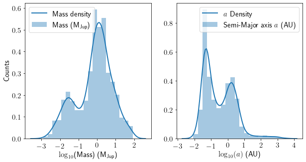

```python
# -Plot----distributions
fig, (ax1,ax2) = plt.subplots(1, 2, figsize=(10, 5))

let=15

m=np.log10(data.mass.values)
a=np.log10(data.semi_major_axis.values)

ax1 = sb.distplot(m, ax=ax1, bins=20,
                  label=r'Mass (M$_\text{Jup}$)',
                  kde_kws={"lw": 2, "label": r"Mass density"})

ax2 = sb.distplot(a, ax=ax2, bins=20,
                  label=r'Semi-Major axis $a$ (AU)',
                  kde_kws={"lw": 2, "label": r"$a$ Density"})

ax1.set_xlabel(r"$\log_{10}$(Mass) (M$_\text{Jup}$)",fontsize=let)
ax2.set_xlabel(r"$\log_{10}(a)$ (AU)",fontsize=let)
ax1.set_ylabel(r"Counts", fontsize=let)
ax1.tick_params(labelsize=let)
ax2.tick_params(labelsize=let)

ax1.set_xticks(np.arange(int(min(m))-1, int(max(m))+2, 1.0))
ax2.set_xticks(np.arange(int(min(a))-1, int(max(a))+2, 1.0))


ax1.legend(loc='upper left',fontsize=let);ax2.legend(loc='upper right',fontsize=let)
#plt.savefig("figures/hists.pdf", bbox_inches='tight')
```

## 2. Get the center of Mass

We need to estimate the CM for each system. The definition of center of mass: \begin{equation*} \text{CM} = \frac{\sum\limits_{k=1}^n(m_{k}\vec{r_{k}})}{\sum \limits_{k=1}^{n}m_{k}} %=\frac{\sum\limits_{k=1}^n(m_{k}\vec{r_{k}})}{M_{T}} \end{equation*} For do it, is nessesary get the values mass $m$ times disnace $r$, for each planet, so with the columns of `mass` and distance from the star `semi_major_axis` we can get $m_{k}\vec{r_{k}}$ values. Then, we take the sum for all planets in each systems, as a result we got $\text{CM}_i$ for $i\in\{0,1,2,3,4,\ldots,n\}$.

**Remember:** The `data.groupby("key")` split the data in groups which are the key.

**Remember:** The `data[i].multiply(data[j])` multiplies the comun i and j of DataFrame or Series i and j, row by row.

**Remember:** The `data.groupby.groups.keys()` get the keys of the split data.

```python
# Group by the name system:
p_system = data.groupby("star_name")
print('The number of planetary systems = '+ str(len(p_system)))

# The numer of exoplanets around each star:
number=(data["star_name"].value_counts()).to_frame()
#print(number)

# The number of systems with more than one exoplanet:
count = 0
for i, index in enumerate(number.star_name.values):
    if index>1.:
        count+=1
print("Systems with more than one planet = "+str(count))
```

```
The number of planetary systems = 987
Systems with more than one planet = 154
```

```python
#-----------------------function center of mass-----------------------
#it returns a data frame group bay systems:

def CoM(data): #data is a dataframe with mass and semi major axis

    # Multiplications between columns mass and axis, CM_i new column:
    data = data.assign(CM_i=data["semi_major_axis"]*data["mass"])
    #print(data)
    # Group by each planet in the system:
    p_system = data.groupby("star_name")
    system = list(p_system.groups.keys())
    # Total mass per system:
    M_total = p_system["mass"].sum()
    sum_rm = p_system['CM_i'].sum() # sum of masses in each system.
    # Center of mass:
    CoM = sum_rm.divide(M_total)

    system = list(p_system.groups.keys())

    NewData = pd.DataFrame({'System_name':system,
                            'Total_mass':M_total.tolist(),
                            'Center_of_Mass':CoM.tolist()})

    return NewData

CoM=CoM(data);#CoM
```

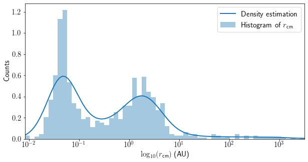

```python
#histogram
lat=15

x=CoM.Center_of_Mass.values

fig, ax = plt.subplots(1, 1, figsize=(10, 5))

ax = sb.distplot(np.log10(x), bins=60, label=r"Histogram of $r_\text{cm}$",
                kde_kws={"lw": 2, "label": r"Density estimation"})

ax.set_xticklabels([r'$10^{-3}$',r'$10^{-2}$',r'$10^{-1}$',r'$10^{0}$',
                    r'$10^{1}$',r'$10^{2}$',r'$10^{3}$'])#,
#                    r'$10^{3}$',r'$10^{4}$'])

ax.set(xlim=(np.log10(x).min(),np.log10(x).max()))

plt.xlabel(r"$\log_{10}(r_\text{cm})$ (AU)", fontsize=lat)
plt.ylabel(r"Counts", fontsize=lat)
ax.tick_params(labelsize=lat)
plt.legend(fontsize=lat)
plt.savefig("figures/CMhist.pdf",bbox_inches='tight')
```

However, the calculus of the CM, was made without take into account the mass of the star.

## 3. Gaussian Mixture Model

At first we will produce the information criteria in irder to clasify or determine the number of sets into te GMM.

### Function: Information Criterion AIC/BIC

First, we define a function wich gets the information criteria for different numbers of components (the number of mixture components), in order to obtain the minimum value of criterium. The lowest BIC/AIC is preferred.

Then, it plots the BIC and AIC values to observe their behavior.

```python
# "mass" must be a column of the dataframe (in this case an array of masses)
# "times" is the number of clusters in the criteria: AIC and BIC
# returns de value of the AIC and BIC criteria. also, returns the plot of the criteria.

def inf_criterion(times, mass):

    bic, aic = [], []

    for i in range(times):
        i += 1
        gmm = GaussianMixture(i, covariance_type='full', random_state=0)
        gmm.fit(mass.values)
        bic+=[gmm.bic(mass.values)]
        aic+=[gmm.aic(mass.values)]

    criteria = [bic,aic]
    min_criteria = [min(criteria[0])/max(criteria[0]),
                    min(criteria[1])/max(criteria[1])]

    #comparison between AIC and BIC criteria----------------(plot)------------------------
    figure, ax = plt.subplots(1, 2, sharex='col',
                              sharey='row', figsize=(10, 5))
    label = ['BIC','AIC']

    for i,criterium in enumerate(criteria):

        ax[i].plot(range(1, len(criteria[i])+1),
                   criteria[i]/max(criteria[i]),
                   "o", c="C1",label=label[i]+" values")

        ax[i].plot(range(1,len(criteria[i])+1),
                   criteria[i]/max(criteria[i]),
                   lw="2")#, label=label[i])

        ax[i].plot(range(len(criteria[i])),
                   np.ones(len(criteria[i]))*min_criteria[i],"--")

        ax[i].set_xlabel('Number of clusters', fontsize=18)
        ax[i].legend(fontsize=15, loc=1,edgecolor='black')
        ax[i].tick_params(labelsize=14)
        ax[i].set_xlim(0,times-0.5)
        ax[i].set_xticks(np.arange(0, times, step=2))

    ax[0].set_ylabel('Criterium value normalized', fontsize=20)
    plt.subplots_adjust(wspace = .05)

    print('N. of clusters BIC = '+str(criteria[0].index(min(criteria[0]))+1))
    print('N. of clusters AIC = '+str(criteria[1].index(min(criteria[1]))+1))

    return [bic,aic]
```

```python
#info_mass = inf_criterion(16,  np.log10(CoM[["Center_of_Mass"]]))
```

### Function: Classification

Once the criterion is applied, the classification comes. Here, we employ the number of compnents, `n_components`, where the lowest BIC/AIC is preferred.

The gaussian plots are generated in order to represent the clusters.

```python
# "mass" must be a clumn of the dataframe (in this case an array of masses)
#'n_components' is the number of clusters for the lowest BIC/AIC.

def classification(n_components,mass,log=False):
    gmm = GaussianMixture(n_components,
                          covariance_type='full',
                          random_state=0)
    gmm.fit(mass.values)
    cluster_label = gmm.predict(mass.values)

    #Figures:
    CL = cluster_label
    color=["C"+str(CL[i]+1) for i in range(len(cluster_label))]
    x=np.linspace(mass.values.min(),mass.values.max(),1000)

    figure, ax = plt.subplots(1, 2, sharex='col',
                              sharey='row', figsize=(10, 5))

    #Gaussians:
    for c in range(n_components):
        ax[0].plot(x,norm.pdf(x,gmm.means_[c],
                              gmm.covariances_[c])[0]/
                   norm.pdf(x,gmm.means_[c],
                            gmm.covariances_[c])[0].max())

    #Scatter:
        Mass_a=mass.values[CL==c]
        ax[0].plot(Mass_a,
                   np.zeros(len(Mass_a)),"o",label='cluster '+str(c+1))#,
#                   color='C'+str(c))
        ax[1].plot(mass,gmm.predict_proba(mass)[:,c],"o",
                   label='P_cluster '+str(c+1))

    if log==True:
        ax[0].set(xlabel=r'$\log_{10}$(Mass)')
        ax[1].set(xlabel=r'$\log_{10}$(Mass)')
    else:
        ax[0].set(xlabel=r'Mass')
        ax[1].set(xlabel=r'Mass')

    ax[0].set(ylabel=r'Normal distribution')
    ax[1].set(ylabel=r'Posterior probabilities')

    ax[0].legend()
    ax[1].legend()

    plt.subplots_adjust(wspace = .1)
```

```python
#class_mass = classification(4, np.log10(CoM[["Center_of_Mass"]]),True)
```

### Function: Fraction changed

This function generates 1000 synthetic systems ( *Dawns* ) per each data (the mass an its uncertainty). We take draws from this, and stimate the validation of the classification.

```python
def fraction_changed(data, dawns):

    p_system    = data.groupby("star_name")
    system_list = list(p_system.groups.keys())
    draws       = [] #draws of COM for each system.

    for i in range(len(system_list)):

        system_i      = data[data.star_name == system_list[i]]
        system_i_mass = np.zeros(dawns)
        cm_i          = np.zeros(dawns)

        for k in range(len(system_i)):
            masses = np.random.normal(system_i.mass.values[k],
                                      system_i.mass_error_min.values[k],
                                      dawns)
            axes = np.random.normal(system_i.semi_major_axis.values[k],
                                    system_i.semi_major_axis_error_min.values[k],
                                    dawns)
            cm_i          += masses*axes
            system_i_mass += masses
        #draws.append([np.abs(cm_i/system_i_mass)]
        draws.append([cm_i/system_i_mass])
    draws = np.array(draws)
    draws = draws[draws>0]
    return draws
```

```python
frc = fraction_changed(data,1000)
len(frc)
```

```
986182
```

```python
from scipy.stats import truncnorm
a=0.1
b=2
x = np.linspace(truncnorm.ppf(0.01, a, b),
                truncnorm.ppf(0.99, a, b),
                100)
#print(x)
#plt.plot(truncnorm.ppf(x,a,b),x)

#r = truncnorm.rvs(a, b, size=1000)
#len(r)
```

```python
#list(p_system.groups.keys())
```

```python
system_list = list(p_system.groups.keys())
len(system_list)
```

```
987
```

```python
data[data.star_name == list(p_system.groups.keys())[i]]
```

|  | star_name | mass | mass_error_min | semi_major_axis | semi_major_axis_error_min |
| --- | --- | --- | --- | --- | --- |
| 3821 | ups And | 0.620 | 0.090 | 0.0590 | 0.00100 |
| 3824 | ups And | 1.059 | 0.028 | 5.2456 | 0.00067 |

```python
list(p_system.groups.keys())[1]
```

```
' TYC 4282-605-1'
```

```python
#'dawns' is the number of synthetic systems per each data known
#'data' is a DataFrame of the data, with column "Center of Mass"
#'n_components' is the number of clusters for the lowest BIC/AIC.

def fraction_changed(n_components, dawns, data, log=False):

    draws=[]

    #1000 draws per planetary mass or systrem mass

    for i in range(len(data.values)):
        masses=np.random.normal(data.mass.values[i],
                                data.mass_error_min.values[i],
                                dawns)
        masses = masses[masses>0]
        draws += [masses]

    if log==True:
        mass = np.log10(data[["mass"]])
        draws = [np.log10(i) for i in draws]

    else:
        mass = data[["mass"]]

    #Gausian mixture model for masses  data:
    gmm = GaussianMixture(n_components,covariance_type='full',random_state=0)
    gmm.fit(mass.values)
    cluster_label = gmm.predict(mass.values)

    #fraction of the synthttic systems wich change classification group:
    fraction_changed = []

    #to get only the posotice values of the draws, just get tyhe positives values:
    #draws = [i for i in draws if i > 0] or None

    for index in range(len(draws)):
        #draw_i=np.abs(draws[index][:,np.newaxis])
        draw_i=draws[index][:,np.newaxis]
        orig=gmm.predict(np.array(mass))[index]
        fraction_changed+=[(orig!=gmm.predict(draw_i)).sum()/1000]
    lid=[len(i) for i in draws]
    #print( np.min(lid),np.mean(lid) )
    return(draws)
    #return((np.array(fraction_changed)<=0.1).sum()/len(fraction_changed))
    #return fraction_changed
```

```python
#frac_mass=fraction_changed(4,1000,CoM[["Center_of_Mass"]],False)
```

```python
#np.log10(data[["Center_of_Mass"]])==np.log10(CoM[["Center_of_Mass"]])
```

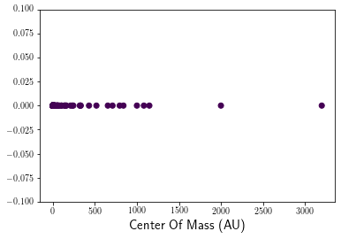

```python
#GaussianMixture:  a firs approximation for 10 grups
#----------------------------------------------------------------------
data = CoM
gmm = GaussianMixture(1, covariance_type='full', random_state=0)
CM=CoM[["Center_of_Mass"]]
gmm.fit(CM.values)
cluster_label = gmm.predict(CM.values)
plt.scatter((CM.values),np.zeros(len(CM)), c=cluster_label);
plt.ylim(-0.1,0.1)
plt.xlabel(r"Center Of Mass (AU)", fontsize="15")
#For the CoM is nessesary emply a Logarithm sclae.
```

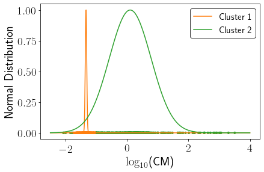

```python
#the log10scale for center of mass of each exoplanetary system:
#----------------------------------------------------------------------
CM_log=np.log10(data[["Center_of_Mass"]])

GMM,cluster=[],[]

#Some different components for Gaussian Mixture Model:
#----------------------------------------------------------------------
for i in [2,3]:
    gmm = GaussianMixture(i, covariance_type='full', random_state=0)
    GMM.append(gmm)
    gmm.fit(CM_log.values)
    cluster_label = gmm.predict(CM_log.values)
    cluster.append(cluster_label)

# (just a plot for two grups)
#----------------------------------------------------------------------
#plt.rc('text', usetex=True)

color=[]
#len(cluster[0])
for i in range(len(cluster[0])):
    if cluster[0][i] == 0:
        color.append("C1")
    elif cluster[0][i] == 1:
        color.append("C2")

x=np.linspace(-2.5,4,1000)
colors=["C1","C2","C3","C4","C5"]

fig, ax1 = plt.subplots(1, 1, sharex='col', sharey='row')

plt.gcf().subplots_adjust(bottom=0.15,right=0.96, left=0.115, top=0.93)

for i, (v1,v2) in enumerate(zip(GMM[0].means_,GMM[0].covariances_)):
    ax1.plot(x, norm.pdf(x,v1,v2)[0]/norm.pdf(x,v1,v2)[0].max(),
             c=colors[i],label="Cluster "+str(i+1))
    ax1.legend(fontsize=15,edgecolor='black')

ax1.scatter((CM_log.values),np.zeros(len(CM_log)),c=color,
            label="Cluster",s=10)

ax1.tick_params(labelsize=19)

plt.xlabel(r'$\log_{10}$(CM)',fontsize=20)
plt.ylabel(r'Normal Distribution',fontsize=20)
plt.savefig("figures/GMM1.pdf")
```

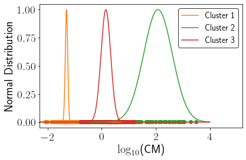

```python
# (just a plot for five grups)
#----------------------------------------------------------------------
color=[]
C = cluster[1]
for i in range(len(cluster[1])):
    if C[i] == 0:
        color.append("C1")
    elif C[i] == 1:
        color.append("C2")
    elif C[i] == 2:
        color.append("C3")
    elif C[i] == 3:
        color.append("C4")
    elif C[i] == 4:
        color.append("C5")

x=np.linspace(-2.5,4,1000)
colors=["C1","C2","C3","C4","C5"]

fig2, ax2 = plt.subplots(1, 1, sharex='col', sharey='row')

plt.gcf().subplots_adjust(bottom=0.17,right=0.97, left=0.175, top=0.90)

for i, (v1,v2) in enumerate(zip(GMM[1].means_,GMM[1].covariances_)):
    ax2.plot(x, norm.pdf(x,v1,v2)[0]/norm.pdf(x,v1,v2)[0].max(),
             c=colors[i],label="Cluster "+str(i+1))
    ax2.legend(fontsize=14, loc=1,edgecolor='black')

ax2.scatter((CM_log.values),np.zeros(len(CM_log)),c=color, label="Group 1")
ax2.set_xlim(-2.3,5.2)

ax2.tick_params(labelsize=19)

#plt.title(r"GMM with three components",fontsize=22)
plt.xlabel(r'$\log_{10}$(CM)',fontsize=20)
plt.ylabel(r'Normal Distribution',fontsize=20)
#plt.savefig("figures/GMM3.pdf")
```

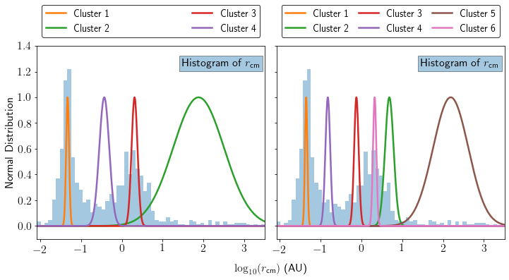

```python
#Some different components for Gaussian Mixture Model:
data = CoM
CM_log=np.log10(data[["Center_of_Mass"]])
GMM,cluster=[],[]
let=16
#----------------------------------------------------------------------
for i in [4,6]:
    gmm = GaussianMixture(i, covariance_type='full', random_state=0)
    GMM.append(gmm)
    gmm.fit(CM_log.values)
    cluster_label = gmm.predict(CM_log.values)
    cluster.append(cluster_label)
#----------------------------------------------------------------------
col=[]

for i in range(len(cluster[0])):
    if cluster[0][i] == 0:
        col.append("C1")
    elif cluster[0][i] == 1:
        col.append("C2")
    elif cluster[0][i] == 2:
        col.append("C3")
    elif cluster[0][i] == 3:
        col.append("C4")

lor=[]
C = cluster[1]
for i in range(len(cluster[1])):
    if C[i] == 0:
        lor.append("C1")
    elif C[i] == 1:
        lor.append("C2")
    elif C[i] == 2:
        lor.append("C3")
    elif C[i] == 3:
        lor.append("C4")
    elif C[i] == 4:
        lor.append("C5")
    elif C[i] == 5:
        lor.append("C6")
    elif C[i] == 6:
        lor.append("C7")

x=np.linspace(-2.5,4,1000)
colors=["C1","C2","C3","C4","C5","C6","C7"]

fig, axs = plt.subplots(1, 2, figsize=(10, 5), sharey=True)

plt.gcf().subplots_adjust(bottom=0.12,right=0.99, left=0.07, top=0.88)

#axs[0].scatter((CM_log.values),np.zeros(len(CM_log)),c=col)
#axs[1].scatter((CM_log.values),np.zeros(len(CM_log)),c=lor)

#h1 = axs[0].hist(CM_log.values,60, density=True)#,label=r"Histogram of $r_\text{cm}$")

sb.distplot(CM_log.values,60,kde=False, norm_hist=True, ax = axs[0])#,label=r"Histogram of $r_\text{cm}$")
sb.distplot(CM_log.values,60,kde=False, norm_hist=True, ax = axs[1])#,label=r"Histogram of $r_\text{cm}$")

#leg1 = plt.legend(loc='upper left', fontsize=let-5)

#izq
for i, (v1,v2) in enumerate(zip(GMM[0].means_,GMM[0].covariances_)):
    axs[0].plot(x, norm.pdf(x,v1,v2)[0]/norm.pdf(x,v1,v2)[0].max(),
             c=colors[i],label="Cluster "+str(i+1),lw=2.5)
    axs[0].legend(fontsize=let-2,edgecolor='black',bbox_to_anchor=(-0, 1.02, 1, .15), loc=3,
              ncol=2,mode="expand")
#der
for i, (v1,v2) in enumerate(zip(GMM[1].means_,GMM[1].covariances_)):
    axs[1].plot(x, norm.pdf(x,v1,v2)[0]/norm.pdf(x,v1,v2)[0].max(),
             c=colors[i],label="Cluster "+str(i+1),lw=2.5)
    axs[1].legend(fontsize=let-2,edgecolor='black',bbox_to_anchor=(0, 1.02, 1, .102), loc=3,
              ncol=3, mode="expand")

axs[0].set_ylim(-0.1,1.4,1/10)
axs[0].set_xlim(CM_log.values.min(),CM_log.values.max())
axs[1].set_xlim(CM_log.values.min(),CM_log.values.max())
#axs[0].set_xscale('log')
axs[0].tick_params(labelsize=let)
axs[1].tick_params(labelsize=let)

plt.subplots_adjust(wspace=0.05)

#axs.xlabel(r'$\log_{10}$(CM)',fontsize=20)
axs[0].set_ylabel(r'Normal Distribution',fontsize=let)
fig.text(0.53, 0.0, r"$\log_{10}(r_\text{cm})$ (AU)",
         fontsize=let, ha='center', va='center')

fig.text(.355, .8, r"Histogram of $r_\text{cm}$", color='k',
         fontsize=let, bbox=dict(facecolor="C0",alpha = .4))

fig.text(.825, .8, r"Histogram of $r_\text{cm}$", color='k',
         fontsize=let, bbox=dict(facecolor="C0",alpha = .4))
#plt.gca().add_artist(leg1)

#plt.savefig("figures/GMM_2-3-hist.pdf",bbox_inches='tight')
plt.savefig("figures/GMM_4-6-hist.pdf",bbox_inches='tight')
```

To determine the number of cluster in the Gaussian Mixture Model, it may use a bayessian information criterion

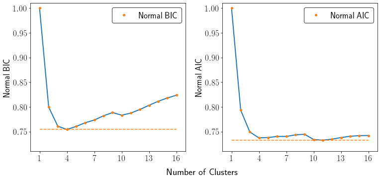

```python
#Bayesian information criterion
CM_log=np.log10(data[["Center_of_Mass"]])
bic,aic = [],[]
tries=16

for i in range(tries):
    i+=1
    gmm = GaussianMixture(i, covariance_type='full', random_state=0)
    CM_log=np.log10(data[["Center_of_Mass"]])
    gmm.fit(CM_log.values)
    bic+=[gmm.bic(CM_log.values)]
    aic+=[gmm.aic(CM_log.values)]
#bic
# (just a plot to bayessian criterion)
#----------------------------------------------------------------------

#fig = plt.figure(figsize=(4,3))
#plt.plot(range(1,11),bic)

let=17
names=[r"Normal BIC",r"Normal AIC"]
criteria = [bic, aic]

x=range(1,tries+1)

fig, axs = plt.subplots(1, 2, figsize=(11, 5))#, sharex=True)# sharex='col', sharey='row')
plt.gcf().subplots_adjust(bottom=0.12,right=0.99, left=0.07, top=0.88)

for i in range(len(criteria)):
    y=criteria[i]/max(criteria[i])
    h = axs[i].plot(x,y, lw="2")
    f = axs[i].plot(x,y, "o", c="C1",label=names[i],markersize=4)

    g = axs[i].plot(x,np.ones(len(criteria[i]))*min(criteria[i])/max(criteria[i]),"--")

    axs[i].set_ylim(.71,1.01)
    axs[i].set_xlim(0,tries+1)
    axs[i].tick_params(labelsize=let)
    axs[i].legend(fontsize=let, loc=1,edgecolor='black')
    #axs[i].set_yticks(range(0,1),.1)
    axs[i].set_ylabel(names[i],fontsize=let)
    axs[i].set_xticks(np.arange(min(x), max(x)+1, 3.0))

fig.text(0.53, 0.0, r'Number of Clusters', fontsize=let+2, ha='center', va='center')
fig.tight_layout(pad=2.0)

#plt.title(r"Bayessian Information Criterion",fontsize=16)
#plt.xlabel(,fontsize=let)
plt.savefig("figures/BIC-AIC.pdf",bbox_inches='tight')
```

```python
print(bic.index(min(bic))+1,aic.index(min(aic))+1)
```

```
4 11
```

```
(-0.1, 1.0)
```

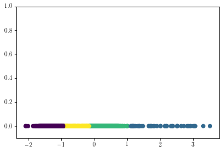

```python
# GaussianMixture, for the log of CM:
# 4 groups due tu the bic
gmm = GaussianMixture(4, covariance_type='full', random_state=0)
CM_log=np.log10(data[["Center_of_Mass"]])
gmm.fit(CM_log.values)
cluster_label = gmm.predict(CM_log.values)
plt.scatter((CM_log.values),np.zeros(len(CM_log)),c=cluster_label);
plt.ylim(-0.1,1)
```

```python
cluster_label[794]
```

```
0
```

The probabilities or verisimilitudes, are defined by normal distribution for each group from the gaussian mixture model:

[figure not shown]

```python
#gmm.means_
#just a plot to bayessian criterion for 4 clusters
#----------------------------------------------------------------------
plt.figure(figsize=(15,7))
plt.gcf().subplots_adjust(bottom=0.15,right=0.96, left=0.08, top=0.93)

color=[]
CL = cluster_label
for i in range(len(cluster[1])):
    if CL[i] == 0:
        color.append("C1")
    elif CL[i] == 1:
        color.append("C2")
    elif CL[i] == 2:
        color.append("C3")
    elif CL[i] == 3:
        color.append("C4")
    elif CL[i] == 4:
        color.append("C5")

colors=["C1","C2","C3","C4","C5"]

#fig4, ax4 = plt.subplots(1, 1, sharex='col', sharey='row')

for i, (v1,v2) in enumerate(zip(gmm.means_,gmm.covariances_)):
    plt.plot(x, norm.pdf(x,v1,v2)[0]/norm.pdf(x,v1,v2)[0].max(),
             c=colors[i],label="Cluster "+str(i+1),lw=2)
    plt.legend(fontsize=24, loc=1,edgecolor='black')

plt.scatter((CM_log.values),np.zeros(len(CM_log)),c=color, label="Group 1")
#plt.hist(CM_log.values,100, density=True)

plt.xlim(-2.2,3.7)

plt.tick_params(labelsize=24)

plt.title(r"GMM for the BIC clusters",fontsize=25)
plt.xlabel(r'$\log_{10}$(CM)',fontsize=26)
plt.ylabel(r'Normal Distribution',fontsize=26)
#plt.savefig("figures/GMM4.pdf")
```

The posteriror probabilities are determinated by the function `gmm.predict_proba()`

[figure not shown]

```python
# The posterior probabilities:
names=["Earth-centered", "Close","Far away","Venusian-centered"]
plt.figure(figsize=(7,5.6))

for i in range(4):
    plt.scatter(CM_log,gmm.predict_proba(CM_log)[:,i],label=names[i], s=7);

plt.gcf().subplots_adjust(bottom=0.15,right=0.97, left=0.15, top=0.83)
plt.tick_params(labelsize=20)
plt.xlabel(r'$\log_{10}(r_\text{cm}) \text{(AU)}$',fontsize=22)
plt.ylabel(r'Posterior Probabilities',fontsize=22)
plt.xlim(-2.5,4)

plt.xticks(np.arange(int(min(m)), int(max(m))+2, 1.0))

plt.legend(fontsize=17.5,edgecolor='black',
           bbox_to_anchor=(-0.02, 1.20, 1.037, 0.06), loc=2,
           ncol=2, mode="expand")
plt.savefig("figures/Prob.pdf")
```

```python
gmm.predict_proba(CM_log)[794]
CM_log.values[794]
```

```
array([-1.56995864])
```

The probability for a synthetic draw of a system called AA, with a $\mu=0.8$ and $\sigma=0.03$ in the CM, can be established as:

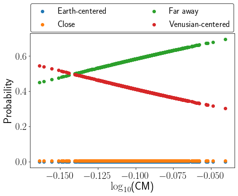

```python
AA=np.log10(np.random.normal(0.8,0.03,1000))
AA=AA[:,np.newaxis]
names=["Earth-centered", "Close","Far away","Venusian-centered"]
plt.figure(figsize=(7,5.6))

#production of probability for a syntethic planetary system
for i in range(4):
    plt.scatter(AA,gmm.predict_proba(AA)[:,i],label=names[i])

plt.gcf().subplots_adjust(bottom=0.15,right=0.965, left=0.14, top=0.83)
plt.legend(fontsize=17.5,edgecolor='black',
           bbox_to_anchor=(-0.02, 1.20, 1.037, 0.055), loc=2,
           ncol=2, mode="expand")
plt.tick_params(labelsize=20)
plt.xlabel(r'$\log_{10}$(CM)',fontsize=22)
plt.ylabel(r'Probability',fontsize=22)
#plt.savefig("figures/draw.pdf")
```

```python
AA
```

[output not shown]

[output cut: 945 more lines]

[output not shown]

## ... Draws

Employing m and $\Delta$m, a and $\Delta$a, from `data2`.

```python
# Group the planetary system:
data2 = dataB[['star_name','mass', 'mass_error_min',
               'semi_major_axis','semi_major_axis_error_min']]
Planetary_System = data2.groupby("star_name")
Systems_List = list(Planetary_System.groups.keys())
```

A first way to get the drows for each system:

```python
#%%time
#-------------------------------------------------------------------------
# Draws, for each planetary system
draws=[]#drows of COM for each system.
for i in range(len(Systems_List)):
    system_i = data2[data2.star_name == Systems_List[i]]
    draw_i=[]
    for j in  range(1000):
        #Get random values for each planet in a system and the COM for those values
        masses=np.random.normal(system_i.mass,system_i.mass_error_min)
        axes=np.random.normal(system_i.semi_major_axis,
                              system_i.semi_major_axis_error_min)
        draw_i += [(masses*axes).sum()/masses.sum()]
    draws.append(draw_i)
```

```python
#len(draws[0])
```

Second way to get the draws for each system (in a shorter time):

```python
#%%time
DrawsA=[]#drows of COM for each system.
for i in range(len(Systems_List)):
    SystemA_i = data2[data2.star_name == Systems_List[i]]
    Mass_System = np.zeros(1000)
    Mass_Axe = np.zeros(1000)
    for k in range(len(SystemA_i)):
        Masses = np.random.normal(SystemA_i.mass.values[k],
                                  SystemA_i.mass_error_min.values[k],1000)
        Axes = np.random.normal(SystemA_i.semi_major_axis.values[k],
                                SystemA_i.semi_major_axis_error_min.values[k],
                                1000)
        Mass_Axe += Masses*Axes
        Mass_System += Masses
        #print(SystemA_i.mass.values[k])
    DrawsA.append(np.abs(Mass_Axe/Mass_System))
len(DrawsA)
```

```
987
```

```python
Systems_List.index("TRAPPIST-1")
```

```
794
```

[figure not shown]

```python
Tras = DrawsA[Systems_List.index("TRAPPIST-1")]
fig, ax1 = plt.subplots(1, 1)

let=15

ax1 = sb.distplot(Tras, ax=ax1, bins=50,
                  label=r' Synthetic $r_\text{cm}$ (AU)',
                  kde_kws={"lw": 2, "label": r" Synthetic density"})

ax1.set_xlabel(r"$\log_{10}$(Mass) (M$_\text{Jup}$)",fontsize=let)
#_xlabel(,fontsize=let);ax.set_ylabel(r"Orbital period (years)",fontsize=let)
ax1.set_ylabel(r"Distribution", fontsize=let)
ax1.tick_params(labelsize=let)


ax1.legend(loc='upper left',fontsize=let);
plt.savefig("figures/Tras_hists.pdf", bbox_inches='tight')
```

[output not shown]

[output not shown]

[figure not shown]

```python
#import seaborn as sns
#sns.set()
fig, (ax1,ax2) = plt.subplots(nrows=1, ncols=2, figsize=(8, 5))

f1 = ax1.hist(DrawsA[2][0],10,alpha=0.8,label=Systems_List[2]+" DrawsA")
f2 = ax1.hist(draws[2],10, alpha=0.6,label=Systems_List[2]+" draws")
ax1.legend(bbox_to_anchor=(0., 1.02, 1., .102), loc=3,ncol=1, mode="expand", borderaxespad=0.)
f2 = sns.kdeplot(DrawsA[2][0], shade=True,label=Systems_List[2]+" DrawsA")
f3 = sns.kdeplot(draws[2], shade=True,label=Systems_List[2]+" draws")
ax2.legend(bbox_to_anchor=(0., 1.02, 1., .102), loc=3,ncol=1, mode="expand", borderaxespad=0.)
```

The probability of each draw to belong a each group, taking draws form `DrawsA`

```python
kk=8
Draw_i=np.log10(DrawsA[kk][0][:,np.newaxis])
orig=gmm.predict(np.array(CM_log))[kk]
print(orig)
print((orig!=gmm.predict(Draw_i)).sum()/1000)
for i in range(4):
    plt.scatter(Draw_i,gmm.predict_proba(Draw_i)[:,i])
```

[output not shown]

```python
np.log10(DrawsA[8])[0][:10]
```

[output not shown]

```python
plt.hist(np.log10(DrawsA[8])[0])
```

[output not shown]

```python
# CM_log is the centero of mass in log scale for each system
frac=[]
for kk in range(len(DrawsA)):
    Draw_i=np.log10(DrawsA[kk][0][:,np.newaxis])
    orig=gmm.predict(np.array(CM_log))[kk]
#    print(kk)
    frac+=[(orig!=gmm.predict(Draw_i)).sum()/1000] # AA es el elemento i de draws (que debe ser un array de 1000 elementos)


#for i in range(4):
#    plt.scatter(Draw_i,gmm.predict_proba(Draw_i)[:,i])
#orig
#AA
#orig=gmm.predict(np.array([[0.8]])) # 0.8 es el centro de masa para el sistema i
#(orig!=gmm.predict(AA)).sum()/1000 # AA es el elemento i de draws (que debe ser un array de 1000 elementos)
#DrawsA[0]
#Draw_i=DrawsA[0][0][:,np.newaxis]
#gmm.predict(Draw_i)
#Draw_i
#gmm.predict(Draw_i)
plt.hist(frac)
print((np.array(frac)==0).sum()/len(frac))
np.max(frac)
```

[output not shown]

```python
orig=gmm.predict(np.array(CM_log))[2]
print(CM_log.values)
DrawsA[2][0]
```

#### Metallicity

```python
dataMet = data_ep[pd.notnull(data_ep["star_metallicity"])]
dataMetA = dataMet[pd.notnull(dataMet["star_metallicity_error_min"])]
dataMet = dataMetA[['star_name',"star_metallicity","star_metallicity_error_min"]]
```

```python
gmm2 = GaussianMixture(3, covariance_type='full', random_state=0)
B=dataMet[["star_metallicity"]]
gmm2.fit(B.values)
cluster_label = gmm2.predict(B.values)
B.values[:, 0]
plt.scatter((B.values),np.zeros(len(B)), c=cluster_label);
plt.ylim(-0.1,1)
```

[output not shown]

```python
bic=[]
for i in range(15):
    i+=1
    gmm2 = GaussianMixture(i, covariance_type='full', random_state=0)
    A=data1[["center_of_Mass"]]
    gmm2.fit(B.values)
    bic+=[gmm2.bic(B.values)]
plt.plot(range(1,16),bic)
```

[output not shown]

```python
plt.figure(figsize=(15,5))
sma=np.linspace(-2.5,4,1000)
for m,s in zip(gmm.means_,gmm.covariances_):
    plt.plot(sma, norm.pdf(sma,m,s)[0])
plt.scatter((A.values),np.zeros(len(A)), c = cluster_label);
```

[output not shown]